# Templates for graphics.

This document, which will grow as we encounter new graphical patterns, contains templates for `ggplot()` graphics.

To use the template, create your glyph-ready data, and put in your own variables in place of the ones listed here IN CAPS.

## Scatter Plots

### Template

Make a scatterplot with some bells and whistles.

```r
YOUR_DATA_TABLE %>%              # REQUIRED
  ggplot(aes(x=X_VAR,y=Y_VAR)) + # REQUIRED -- insert your variable names
  geom_point() +                 # REQUIRED
  aes(colour=GROUP_VAR) +        # Optional -- map variable onto color
  aes(size=SIZE_VAR) +           # Optional -- map variable onto size
  scale_x_log10() +              # Optional -- use logarithmic scale for x axis.
  scale_y_log10() +              # Optional -- use logarithmic y scale for y-axis
  facet_wrap(~FACET_VAR, ncol=4) # Optional -- faceting variable
```

You can delete any of the **optional** lines if you don’t want that aspect of the plot. Then, replace each of the placeholders — `YOUR_DATA_TABLE`, `X_VAR`, `Y_VAR`, `GROUP_VAR`, `FACET_VAR` — with the relevant variable from your data table. (If you delete an optional line, you don’t need to worry about the placeholder variable; it will disappear from the statement.)

### Example

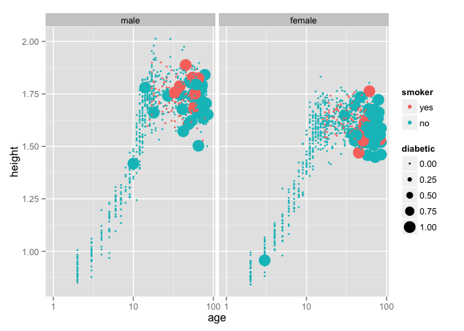

```r
# Create the glyph-ready data
data( NHANES )
Small <- sample_n( NHANES, size=2000 ) # glyph ready table

# Template pasted in and placeholders filled in with real variables.
Small %>%                        # REQUIRED
  ggplot(aes(x=age,y=height)) +  # REQUIRED -- insert your variable names
  geom_point() +                 # REQUIRED
  aes(colour=smoker) +           # Optional -- map variable onto color
  aes(size=diabetic) +           # Optional -- map variable onto size
  scale_x_log10() +              # Optional -- use logarithmic scale for x axis.
  facet_wrap(~sex, ncol=4)       # Optional -- faceting variable
```

One of the optional lines (`scale_y_log10()`) was deleted so the y-axis is on the usual linear scale.

## Bar Charts

[Under construction … I need a better example]

### Template

```r
DATA_TABLE %>%                           # REQUIRED
  ggplot(aes(x=X_VAR,                    # REQUIRED
             y=Y_VAL,
             fill=FILL_VAR)) +           # REQUIRED
  geom_bar(stat='identity',              # REQUIRED
           position=                     # REQUIRED
             position_HOW(width=.9)) +   # REQUIRED options: stack, proportion, dodge
  facet_wrap(~FACET_VAR,ncol=3)  +       # Optional
```

Note the `HOW` placeholder. Choose one of `stack`, `proportion`, or `dodge` so that the function looks like `position_stack()`, `position_proportion()`, or `position_dodge()`.

### Example

Make your glyph-ready data …

```r
FirstPlaceTally <-
  Minneapolis2013 %>%
  group_by( First ) %>%
  summarise( total=n() )
ByPrecinct <-
  FirstPlaceTally %>%
  filter(total > 5000) %>% # Just the big candidates.
  inner_join( Minneapolis2013, . ) %>%
  group_by( Precinct, First) %>%
  summarise( total=n() ) %>%
  mutate( First=droplevels(First) )
```

Copy and customize the template …

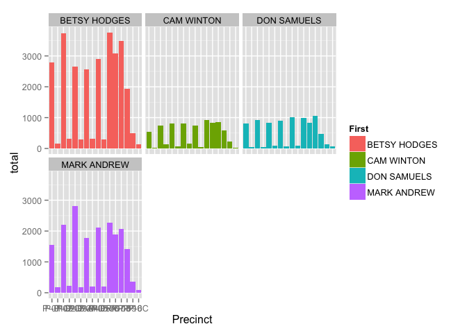

```r
ByPrecinct %>%
  ggplot(aes(x=Precinct,
             y=total,
             fill=First)) +
  geom_bar(stat='identity',
           position=position_stack(width=.9)) +
  facet_wrap(~First,ncol=3)
```

Please use the comment system to make suggestions, point out errors, or to discuss the topic.

[comments powered by Disqus](http://disqus.com)

Written by Daniel Kaplan for the Data & Computing Fundamentals Course. Development was supported by grants from the National Science Foundation for Project Mosaic (NSF DUE-0920350) and from the Howard Hughes Medical Institute.